title: “habtools: Complexity Metrics for 3D Meshes 教學” author: “Guan-Yan Chen” date: “2025-05-05” output: html_document —

# 簡介 / Introduction

本教學示範如何使用 `habtools` 套件計算三維網格 (3D mesh) 的複雜度指標。 This tutorial demonstrates how to compute complexity metrics for 3D meshes using the `habtools` package.

## 前置作業與資料載入 / Setup and Data Loading

**中文說明**：載入必要的套件並載入範例網格資料 `mcap`。 **English Explanation**: Load the required packages and the example mesh data `mcap`.

```r
# 載入套件 / Load packages
library(habtools)
library(rgl)
options(rgl.printRglwidget = TRUE)

# 載入範例網格資料 / Load example mesh data
# `mcap` 範例資料包含在 habtools 套件中
data("mcap", package = "habtools")
```

## 檢查網格 / Checking your mesh

在計算任何指標前，先視覺化網格並檢查 z 軸方向是否正確。 Before calculating any metrics, visualize the mesh and ensure the z orientation is correct.

```r
# 顯示三維網格視覺化 / Visualize the 3D mesh
plot3d(mcap)
```

[interactive chart not shown]

## 解析度分佈 / Resolution Distribution

**中文說明**：計算網格中相鄰頂點間距並繪製直方圖以檢查解析度變異。 **English Explanation**: Compute distances between adjacent vertices in the mesh and plot a histogram to inspect variation in resolution.

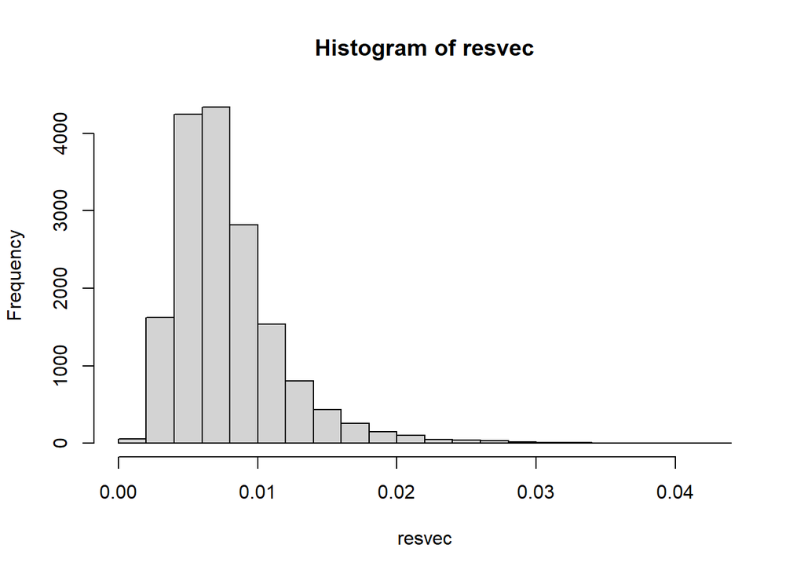

```r
# 計算解析度向量 / Calculate vector of resolutions
resvec <- Rvcg::vcgMeshres(mcap)[[2]]

# 繪製直方圖 / Plot histogram of resolutions
hist(resvec)
```

```r
# 顯示解析度摘要統計 / Display summary statistics of resolutions
summary(resvec)
```

```
##     Min.  1st Qu.   Median     Mean  3rd Qu.     Max.
## 0.001307 0.005265 0.007003 0.007831 0.009410 0.043981
```

## 均勻重網格 / Uniform Remeshing

**中文說明**：使用最小解析度作為 voxelSize 重新均勻網格，以減少點間距差異。 **English Explanation**: Uniformly remesh using the minimum resolution as `voxelSize` to reduce variation in vertex spacing.

```r
# 均勻重網格 / Uniformly remesh mesh
mcap_uniform <- Rvcg::vcgUniformRemesh(
  mcap,
  silent = TRUE,
  multiSample = TRUE,
  voxelSize = min(resvec),
  mergeClost = TRUE
)

# 驗證重網格後解析度 / Check resolution of the remeshed object
Rvcg::vcgMeshres(mcap_uniform)[[1]]
```

```
## [1] 0.001328214
```

```r
summary(Rvcg::vcgMeshres(mcap_uniform)[[2]])
```

```
##      Min.   1st Qu.    Median      Mean   3rd Qu.      Max.
## 0.0003464 0.0010450 0.0013561 0.0013282 0.0016327 0.0026663
```

## 複雜度指標：R, D, 和 H / Complexity metrics: R, D, and H

### 分形維度 / Fractal Dimension

**中文說明**：使用 `cubes` 方法計算 mesh 的分形維度。 **English Explanation**: Compute the fractal dimension of the mesh using the `cubes` method.

```
## lvec is set to c(0.003, 0.006, 0.012, 0.024, 0.048, 0.096, 0.193, 0.386).
```

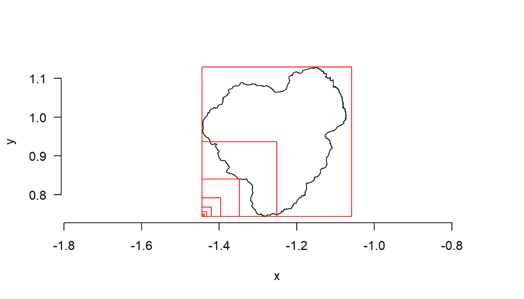

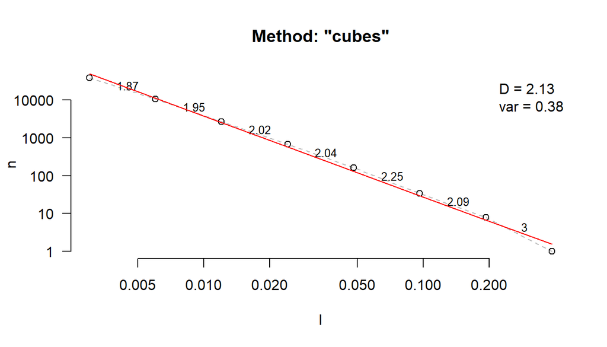

```r
# 分形維度計算 / Calculate fractal dimension
fd_result <- fd(
  mcap_uniform,
  method = "cubes",
  plot = TRUE,
  diagnose = TRUE
)
```

```r
# 提取 D 值 / Extract fractal dimension
fd_result$D
```

```
## [1] 2.133279
```

### Rugosity 及高度範圍 / Rugosity and Height Range

```r
# Rugosity 計算 / Compute rugosity
rg(mcap_uniform)
```

```
## L0 is set to mesh resolution (0.00132821395068341)
```

```
## [1] 3.148722
```

```r
# 計算高度範圍 / Compute height range
hr(mcap_uniform)
```

```
## [1] 0.2204218
```

### 平面與表面積 / Planar and Surface Area

```r
# 平面表面積 / Planar surface area
planar(mcap)
```

```
## L0 is set to mesh resolution (0.00783124724167033)
```

```
## [1] 0.08303158
```

```r
# 總表面積 / Total surface area
surface_area(mcap)
```

```
## [1] 0.2698101
```

## 形狀指標 / Shape Metrics

**中文說明**：計算多種描述物體形狀的指標。 **English Explanation**: Compute various metrics that describe the shape of the object.

```r
convexity(mcap)    # 凸度 / Convexity
```

```
## [1] 0.4484716
```

```r
packing(mcap)      # 打包度 / Packing
```

```
## [1] 0.8642852
```

```r
sphericity(mcap)   # 球形度 / Sphericity
```

```
## [1] 0.6056971
```

```r
sma(mcap)          # 面積二階矩 / Second moment of area
```

```
## [1] 0.03294466
```

```r
smv(mcap)          # 體積二階矩 / Second moment of volume
```

```
## [1] 0.0005450781
```

```r
csf(mcap)          # 機械形狀因子 / Mechanical shape factor
```

```
## z_min set to -3.74007153511047
```

```
## resolution set to 0.00783124724167033
```

```
## [1] 1816.815
```

## 轉換為 DEM 或 2D 形狀 / Transform mesh into a DEM or 2D shape

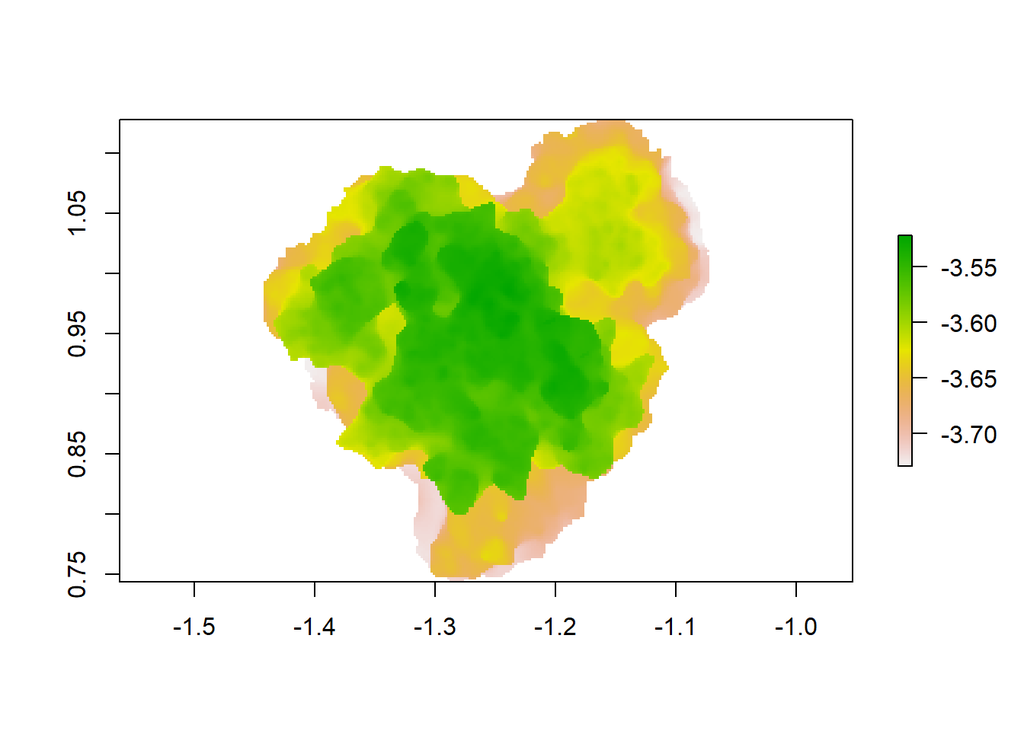

```r
# 轉換為數字高程模型 / Convert mesh to DEM
dem <- mesh_to_dem(mcap_uniform, res = 0.002, fill = FALSE)
# 繪製 DEM / Plot DEM
raster::plot(dem)
```

```r
# 在 DEM 上計算 Rugosity (area 方法) / Compute rugosity on DEM
rg(dem, method = "area")
```

```
## data contains 13391 NA values. Results may be biased.
```

```
## L0 is set to the resolution of the raster: 0.002.
```

```
## [1] 2.767167
```

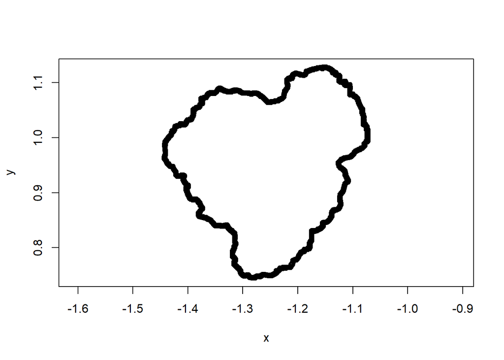

```r
# 轉換為 2D 點集 / Convert mesh to 2D points
pts <- mesh_to_2d(mcap_uniform)
plot(pts, asp = 1)
```

```r
# 周長計算 / Compute perimeter
perimeter(pts)
```

```
## [1] 1.705922
```

```r
# 圓形度計算 / Compute circularity
circularity(pts)
```

```
## [1] 0.6123799
```

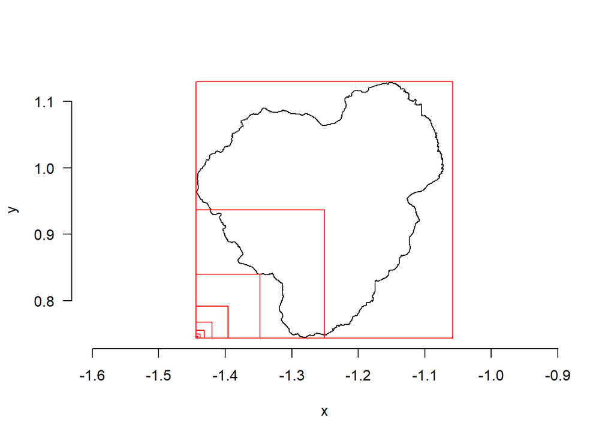

```
## [1] 1.263879
```

```r
# 2D 分形維度 (boxes 方法) / Compute fractal dimension in 2D
fd(pts, method = "boxes", keep_data = FALSE, plot = TRUE)
```

## 參考文獻 / References

- Zawada KJA, Dornelas M, Madin JS (2019) Quantifying coral morphology. *Coral Reefs*, **38**:1281–1292.
- Madin JS & Connolly SR (2006) Ecological consequences of major hydrodynamic disturbances on coral reefs. *Nature*, **444**:477–480.